# Resubmission Index

# Modeling and Evaluation 4 - SVM - CreditRange

```
In this section we analyze our obtained results from the previous section using our chosen evaluation metrics of
Accuracy.  Also, we will provide and explain visualizations that help in understanding why our
model is or is not useful for our dataset.
```

For SVM we will analyze Accuracy. The visualizations of the Confusion Matrix and Support Vectors will be analyzed to provide insight into the model, its interpretation, and usefulness.

```python
# lets investigate SVMs on the data and play with the parameters and kernels
from sklearn.svm import SVC

# train the model just as before
svm_clf = SVC(C=0.5, kernel='rbf', degree=3, gamma='auto') # get object
svm_clf.fit(X_train_scaled, y_train)  # train object

y_hat = svm_clf.predict(X_test_scaled) # get test set precitions

acc = mt.accuracy_score(y_test,y_hat)
conf = mt.confusion_matrix(y_test,y_hat)
print('accuracy:', acc )
print(conf)
```

```
accuracy: 0.391
[[ 23  82 137  17]
 [ 14 123 341  65]
 [  6  73 446 145]
 [  3  26 309 190]]
```

We can see that the SVM model has an accuracy of only 39.1%.

```python
# look at the support vectors
print(svm_clf.support_vectors_.shape)
print(svm_clf.support_.shape)
print(svm_clf.n_support_ )
```

```
(7766, 12)
(7766,)
[1077 2040 2627 2022]
```

```python
# Now let's do some different analysis with the SVM and look at the instances that were chosen as support vectors

# now lets look at the support for the vectors and see if we they are indicative of anything
# grabe the rows that were selected as support vectors (these are usually instances that are hard to classify)

# make a dataframe of the training data
df_tested_on = df_imputed.iloc[train_indices] # saved from above, the indices chosen for training
# now get the support vectors from the trained model
df_support = df_tested_on.iloc[svm_clf.support_,:]

df_support['CreditRange'] = y[svm_clf.support_]
df_imputed['CreditRange'] = y # also add it back in for the original data
df_support.info()
```

```
<class 'pandas.core.frame.DataFrame'>
Int64Index: 7766 entries, 183810 to 193035
Data columns (total 12 columns):
CS                   7766 non-null int64
MIP                  7766 non-null int64
Units                7766 non-null int64
OCLTV                7766 non-null int64
DTI                  7766 non-null int64
OrigUPB              7766 non-null int64
LTV                  7766 non-null int64
OrigInterestRate     7766 non-null float64
OrigLoanTerm         7766 non-null int64
MonthsInRepayment    7766 non-null int64
IsFirstTime          7766 non-null int32
CreditRange          7766 non-null category
dtypes: category(1), float64(1), int32(1), int64(9)
memory usage: 705.5 KB
```

```
<class 'pandas.core.frame.DataFrame'>
Int64Index: 7766 entries, 183810 to 193035
Data columns (total 12 columns):
CS                   7766 non-null int64
MIP                  7766 non-null int64
Units                7766 non-null int64
OCLTV                7766 non-null int64
DTI                  7766 non-null int64
OrigUPB              7766 non-null int64
LTV                  7766 non-null int64
OrigInterestRate     7766 non-null float64
OrigLoanTerm         7766 non-null int64
MonthsInRepayment    7766 non-null int64
IsFirstTime          7766 non-null int32
CreditRange          7766 non-null category
dtypes: category(1), float64(1), int32(1), int64(9)
memory usage: 705.5 KB
```

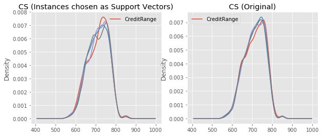

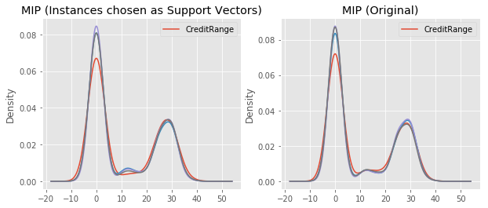

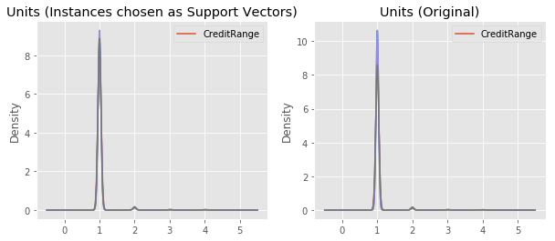

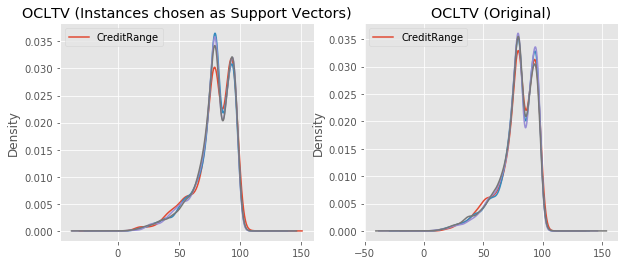

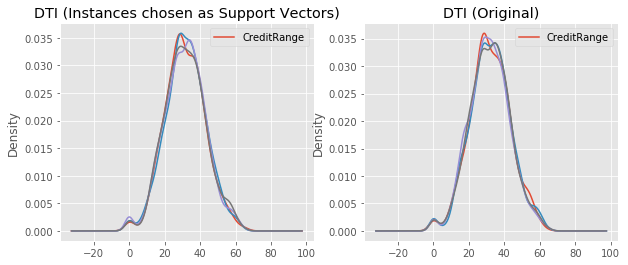

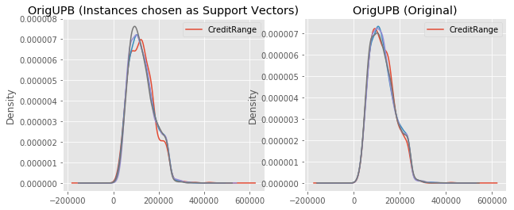

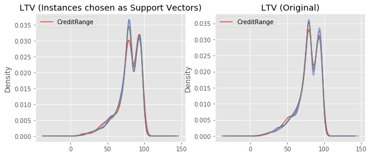

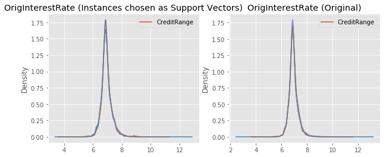

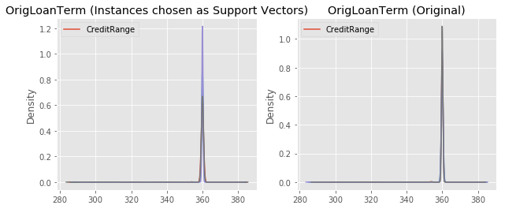

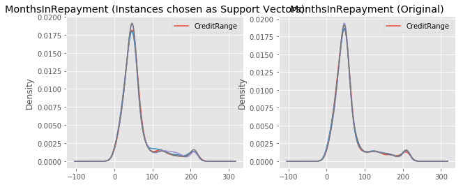

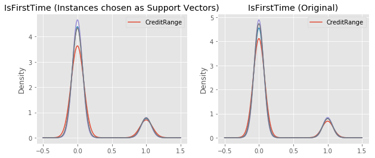

```python
# Now let's do some different analysis with the SVM and look at the instances that were chosen as support vectors

# now lets look at the support for the vectors and see if we they are indicative of anything
# grabe the rows that were selected as support vectors (these are usually instances that are hard to classify)

# make a dataframe of the training data
df_tested_on = df_imputed.iloc[train_indices] # saved from above, the indices chosen for training
# now get the support vectors from the trained model
df_support = df_tested_on.iloc[svm_clf.support_,:]

df_support['CreditRange'] = y[svm_clf.support_]
df_imputed['CreditRange'] = y # also add it back in for the original data
df_support.info()


# now lets see the statistics of these attributes
from pandas.tools.plotting import boxplot

# group the original data and the support vectors
df_grouped_support = df_support.groupby(['CreditRange'])
df_grouped = df_imputed.groupby(['CreditRange'])

# plot KDE of Different variables
vars_to_plot = ['CS','MIP','Units', 'OCLTV', 'DTI', 'OrigUPB', 'LTV', 'OrigInterestRate',  'OrigLoanTerm', 'MonthsInRepayment', 'IsFirstTime']


for v in vars_to_plot:
    plt.figure(figsize=(10,4))
    # plot support vector stats
    plt.subplot(1,2,1)
    ax = df_grouped_support[v].plot.kde()
    plt.legend(['CreditRange'])
    plt.title(v+' (Instances chosen as Support Vectors)')

    # plot original distributions
    plt.subplot(1,2,2)
    ax = df_grouped[v].plot.kde()
    plt.legend(['CreditRange'])
    plt.title(v+' (Original)')
```

The discrepancy between the support vector and original are more present possibly because the support vector is tuning into the edge cases that exist in the data and or because of classification errors in the training set.

Back to Index  
Back to Exceptional Work

# Modeling and Evaluation 3 - KNN - CreditRange

In this KNN model, we are trying to predict the possible credit range of the borrower at the time the loan was given. We will try to classify a borrowers in force loan record into one out of the below 4 classes: Poor (0-650), Fair (650-700), Good (700-750), Excellent (750-900), Once created, we will explore how changing the parameters for each model affects the model by our chosen metrics of Accuracy.

```python
yhat = np.zeros(y.shape) # we will fill this with predictions

scl = StandardScaler()
X = scl.fit_transform(X)

# create cross validation iterator
cv = StratifiedKFold(n_splits=10)

# get a handle to the classifier object, which defines the type
clf = KNeighborsClassifier(n_neighbors=3)

# now iterate through and get predictions, saved to the correct row in yhat
# NOTE: you can parallelize this using the cross_val_predict method
for train, test in cv.split(X,y):
    clf.fit(X[train],y[train])
    yhat[test] = clf.predict(X[test])

total_accuracy = mt.accuracy_score(y, yhat)
print ('KNN accuracy', total_accuracy)
```

```
KNN accuracy 0.3102
```

Back to Index  
Back to Exceptional Work

# Modeling and Evaluation 4 - KNN - CreditRange

```
In this section we analyze our obtained results from the previous section using our chosen evaluation metrics of
Accuracy and Precision.  Also, we will provide and explain visualizations that help in understanding why our
model is or is not useful for our dataset.
```

For our KNN model we will analyze Accuracy and Precision. The visualizations of In-Class Accuracies and the Confusion Matrix will be analyzed to provide insight into the model, its interpretation, and usefulness.

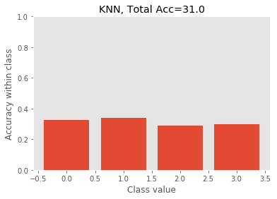

```python
from matplotlib import pyplot as plt
import numpy as np
%matplotlib inline

def per_class_accuracy(ytrue,yhat):
    conf = mt.confusion_matrix(ytrue,yhat)
    norm_conf = conf.astype('float') / conf.sum(axis=1)[:, np.newaxis]
    return np.diag(norm_conf)

def plot_class_acc(ytrue,yhat, title=''):
    acc_list = per_class_accuracy(ytrue,yhat)
    plt.bar(range(len(acc_list)), acc_list)
    plt.xlabel('Class value')
    plt.ylabel('Accuracy within class')
    plt.title(title+", Total Acc=%.1f"%(100*mt.accuracy_score(ytrue,yhat)))
    plt.grid()
    plt.ylim([0,1])
    plt.show()

plot_class_acc(y,yhat,title="KNN")
```

The KNN model has a total accuracy of 31%. Unfortunately, we can see that the within class accuracies are all below 40%. This model does not perform as we would like for it to in classifying the CreditRange.

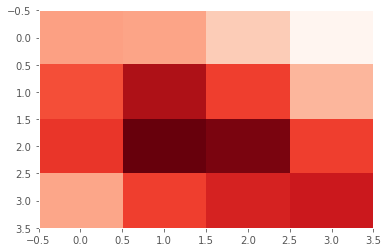

```python
from sklearn import metrics as mt
# how about plotting a confusion matrix?
cm = mt.confusion_matrix(y, yhat)
plt.imshow(cm,cmap=plt.get_cmap('Reds'),aspect='auto')
plt.grid(False)
```

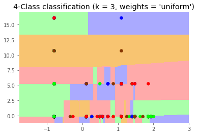

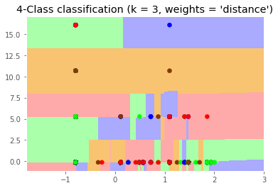

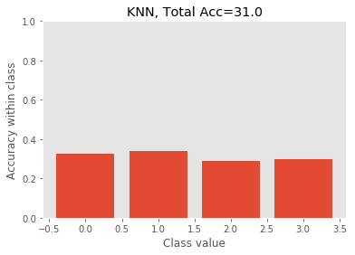

```python
import numpy as np
import matplotlib.pyplot as plt
from matplotlib.colors import ListedColormap
from sklearn import neighbors, datasets

n_neighbors = 3
h = .02  # step size in the mesh
Newx = X[:, :2]
# Create color maps
cmap_light = ListedColormap(['#FFAAAA', '#AAFFAA', '#AAAAFF', '#F8C471'])
cmap_bold = ListedColormap(['#FF0000', '#00FF00', '#0000FF',  '#873600'])

for weights in ['uniform', 'distance']:
    # we create an instance of Neighbours Classifier and fit the data.
    clf = neighbors.KNeighborsClassifier(n_neighbors, weights=weights)
    clf.fit(Newx, y)
    # Plot the decision boundary. For that, we will assign a color to each
    # point in the mesh [x_min, x_max]x[y_min, y_max].
    x_min, x_max = X[:, 0].min() - 1, X[:, 0].max() + 1
    y_min, y_max = X[:, 1].min() - 1, X[:, 1].max() + 1
    xx, yy = np.meshgrid(np.arange(x_min, x_max, h),
                         np.arange(y_min, y_max, h))
    Z = clf.predict(np.c_[xx.ravel(), yy.ravel()])
    # Put the result into a color plot
    Z = Z.reshape(xx.shape)
    plt.figure()
    plt.pcolormesh(xx, yy, Z, cmap=cmap_light)
    # Plot also the training points
    plt.scatter(X[:, 0], X[:, 1], c=y, cmap=cmap_bold)
    plt.xlim(xx.min(), xx.max())
    plt.ylim(yy.min(), yy.max())
    plt.title("4-Class classification (k = %i, weights = '%s')"
              % (n_neighbors, weights))

plt.show()

from matplotlib import pyplot as plt
import numpy as np
%matplotlib inline

def per_class_accuracy(ytrue,yhat):
    conf = mt.confusion_matrix(ytrue,yhat)
    norm_conf = conf.astype('float') / conf.sum(axis=1)[:, np.newaxis]
    return np.diag(norm_conf)

def plot_class_acc(ytrue,yhat, title=''):
    acc_list = per_class_accuracy(ytrue,yhat)
    plt.bar(range(len(acc_list)), acc_list)
    plt.xlabel('Class value')
    plt.ylabel('Accuracy within class')
    plt.title(title+", Total Acc=%.1f"%(100*mt.accuracy_score(ytrue,yhat)))
    plt.grid()
    plt.ylim([0,1])
    plt.show()

plot_class_acc(y,yhat,title="KNN")
```

KNN model accuracy of classifiying a borrowers details correctly into credit range at the time of issue of the loan is 31%

For a perfect classification all of the Red points should be in the Red highlighted regions and all of the Green points in the Green highlighted regions and son. As expected with a 31% accuracy, we see quite a few points in the incorrect region.

The bar graph depicts the accuracy within class of the KNN classification for credit score.

Back to Index

# Modeling and Evaluation 3 - Random Forest - CreditRange

```
In this section we will create our Random Forest model. Once created, we will explore how changing the
parameters for each model affects the model by our chosen metrics of Accuracy.
```

In this Random forest classification model, we are trying to predict the possible credit range of the borrower at the time the loan was given. We will try to classify a borrowers in force loan record into one out of the below 4 classes: Poor (0-650), Fair (650-700), Good (700-750), Excellent (750-900), Once created, we will explore how changing the parameters for each model affects the model by our chosen metrics of Accuracy.

Initially, we will try a Random forest + PCA pipeline, followed by only raw random forest.

Back to Index

# Modeling and Evaluation 4 - Random Forest - CreditRange

```
In this section we analyze our obtained results from the previous section using our chosen evaluation metrics of
Accuracy. Also, we will provide and explain visualizations that help in understanding why our
model is or is not useful for our dataset.
```

For our Random Forest model we will analyze Accuracy. The visualizations of In-Class Accuracy and the Confusion Matrix will be analyzed to provide insight into the model, its interpretation, and usefulness.

```
Pipeline accuracy 0.37
```

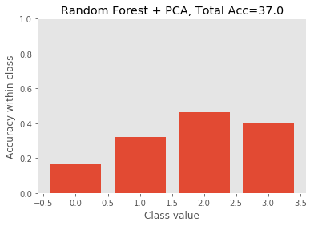

```
Wall time: 13.4 s
```

```python
%%time
from sklearn.decomposition import PCA
from sklearn.pipeline import Pipeline
from sklearn.ensemble import RandomForestClassifier
from sklearn import metrics as mt
from sklearn.neighbors import KNeighborsClassifier
from sklearn.model_selection import StratifiedKFold
from sklearn.preprocessing import StandardScaler

#RandomForest+PCA
yhat = np.zeros(y.shape) # we will fill this with predictions
scl = StandardScaler()
X = scl.fit_transform(X)

# create cross validation iterator
cv = StratifiedKFold(n_splits=10)
clf_pipe = Pipeline(
    [('PCA',PCA(n_components=11, svd_solver='randomized')),
     ('CLF',RandomForestClassifier(max_depth=50, n_estimators=150, n_jobs=-1))]
)

# now iterate through and get predictions, saved to the correct row in yhat
for train, test in cv.split(X,y):
    clf_pipe.fit(X[train],y[train])
    yhat[test] = clf_pipe.predict(X[test])
total_accuracy = mt.accuracy_score(y, yhat)
print ('Pipeline accuracy', total_accuracy)
plot_class_acc(y,yhat,title="Random Forest + PCA")
```

The Random Forest + PCA model gives us only a 37% accuracy. We once again see that the within class accuracies are low as the other models were. The model completed in 13.4 seconds.

```
Accuracy 0.3647
```

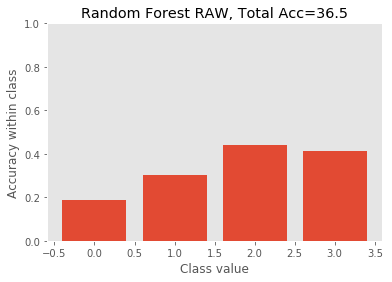

```
Wall time: 10.6 s
```

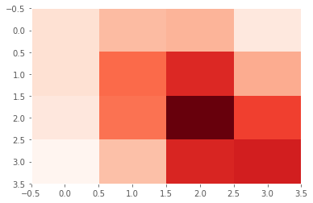

```python
%%time
from sklearn.ensemble import RandomForestClassifier
#raw random forest
clf = RandomForestClassifier(max_depth=50, n_estimators=150, n_jobs=-1, oob_score=True)
# now iterate through and get predictions, saved to the correct row in yhat
for train, test in cv.split(X,y):
    clf.fit(X[train],y[train])
    yhat[test] = clf.predict(X[test])

total_accuracy = mt.accuracy_score(y, yhat)
print ('Accuracy', total_accuracy)
plot_class_acc(y,yhat,title="Random Forest RAW")

from sklearn import metrics as mt
# how about plotting a confusion matrix?
cm = mt.confusion_matrix(y, yhat)
plt.imshow(cm,cmap=plt.get_cmap('Reds'),aspect='auto')
plt.grid(False)
```

Back to Index

# Modeling and Evaluation 3 - Naive Bayes - CreditRange

```
In this section we will create our Naive Bayes model. Once created, we will explore how changing the parameters for each model affects the model by our chosen metrics of Accuracy.
```

In this Naive Bayes classification model, we are trying to predict the possible credit range of the borrower at the time the loan was given. We will try to classify a borrowers in force loan record into one out of the below 4 classes: Poor (0-650), Fair (650-700), Good (700-750), Excellent (750-900), Once created, we will explore how changing the parameters for each model affects the model by our chosen metrics of Accuracy.

```python
from sklearn.naive_bayes import GaussianNB
# setup pipeline to take PCA, then fit a different classifier
clf_pipe = Pipeline(
    [('PCA',PCA(n_components=11,svd_solver='randomized')),
     ('CLF',GaussianNB())]
)
# now iterate through and get predictions, saved to the correct row in yhat
for train, test in cv.split(X,y):
    clf_pipe.fit(X[train],y[train])
    yhat[test] = clf_pipe.predict(X[test])
total_accuracy = mt.accuracy_score(y, yhat)
print ('Pipeline accuracy', total_accuracy)
```

```
Pipeline accuracy 0.3712
```

Back to Index

# Modeling and Evaluation 4 - Naive Bayes - CreditRange

```
In this section we analyze our obtained results from the previous section using our chosen evaluation metrics of
Accuracy.  Also, we will provide and explain visualizations that help in understanding why our
model is or is not useful for our dataset.
```

For our Naive Bayes model we will analyze Accuracy. The visualizations of the Confusion Matrix and In-Class Accuracy will be analyzed to provide insight into the model, its interpretation, and usefulness.

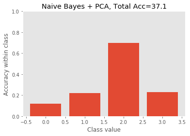

```
[[ 160  419  670   87]
 [ 206  568 1645  174]
 [ 128  459 2375  434]
 [  71  242 1753  609]]
```

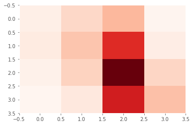

```python
plot_class_acc(y,yhat,title="Naive Bayes + PCA")
from sklearn import metrics as mt
cm = mt.confusion_matrix(y, yhat)
plt.imshow(cm,cmap=plt.get_cmap('Reds'),aspect='auto')
plt.grid(False)
print(cm)
```

Our Naive Bayes + PCA model has a total accuracy of 37.1%. This models highest within class accuracy is around 70% and the next highest is around 25%. Unfortunately, this model does not perform well for predicting the class of CreditRange.

Back to Index

# Modeling and Evaluation 5

#### EverDelinquent Classification Models

The below table summarizes our findings on the different models that we completed for our classification of EverDelinquent.

| Model | Accuracy | Precision |
| --- | --- | --- |
| Logistic Regression | 80.5% | 81.8% |
| SVM | 80.7% | 81.7% |
| KNN | 77.2% | 81.0% |
| Random Forest | 80.0% | 82.3% |
| Naive Bayes | 74.1% | 84.5% |

Using the table above and strictly looking at our performance evaluation metrics of Accuracy and Precision we can eliminate KNN and Naive Bayes as models since the both have the lowest Accuracy. This leaves us with Logistic Regression, SVM, and Random Forest. Previously we noted that Random Forest had an issue with In-Class Accuracy where the model did not classify our delinquent loans (EverDelinquent = 1) very well with only 20% accuracy. This eliminates Random Forest as a potential model for our data.

This leaves us with Logistic Regression and SVM both of which have an Accuracy around 80% and Precision around 82%. Either of these models works well with our data on classifying the EverDelinquent response.

#### CreditRange Classification Models

The below table summarizes our findings on the different models that we completed for our classification of CreditRange.

| Model | Accuracy |
| --- | --- |
| Logistic Regression | 36.0% |
| SVM | 39.1% |
| KNN | 31.0% |
| Random Forest | 37.0% |
| Naive Bayes | 37.1% |

We can see from the provided table that none of our models performed well when attempting to classify the CreditRange and it's classes. Taking a practical approach to interpreting these results, we can see that it does not always make sense to be able to classify a persons Credit Score with the data that we collected. There are many confounding factors such as a persons relationship to the bank or banker, among others, that may lead to a mortgage loan that were not accounted for in our data set.

If we want to continue to attempt to classify the CreditRange then we would need to approach this research from a fresh look on what information should we be collecting in the first place so that we can produce a working model.

Back to Index

### M&E 5: Resubmission

```
Feedback: "Is the difference significant with 95% confidence?" Use proper statistical comparison methods. You must use statistical comparison techniques - be sure they are appropriate for your chosen method of validation as discussed in unit 7 of the course."
```

For model comparison we are assuming that our models data is following a Gaussian distribution. Also, the null hypothesis that we are using to compare our models below is "Are the models means different from one another?". If the confidence intervals we calculate below contain zero then we fail to reject the null hypothesis, meaning that the models are not statistically significantly different from one another. If the confidence intervals do not contain zero then we can reject the null hypothesis and conclude that the models are different from one another, because their means are different, and then use our parameter of Accuracy to conclude which model is a better fit.

Below is a summary table of the different models and the accuracy in classifying CreditRange (CR) and EverDelinquent (ED). We also calculated the variance and confidence intervals for both. Note, for calculating the variance we are assuming the same N for the test data, 233160.

| Model | CR Acc | CR Error | CR Var | ED Acc | ED Error | ED Var |
| --- | --- | --- | --- | --- | --- | --- |
| Logistic Regression | 36.0% | 0.2304 | 0.000000988 | 80.5% | 0.156975 | 0.000000673 |
| SVM | 39.1% | 0.238119 | 0.000001020 | 80.7% | 0.155751 | 0.000000668 |
| KNN | 31.0% | 0.2139 | 0.000000917 | 77.2% | 0.176016 | 0.000000754 |
| Random Forest | 37.0% | 0.2331 | 0.000000999 | 80.0% | 0.16 | 0.000000686 |
| Naive Bayes | 37.1% | 0.233359 | 0.000001000 | 74.1% | 0.191919 | 0.000000823 |

#### Confidence Intervals for Model Comparison of CreditRange:

| Models | Logistic Regression | SVM | KNN | Random Forest | Naive Bayes |
| --- | --- | --- | --- | --- | --- |
| Logistic Regression | - | - | - | - | - |
| SVM | [-0.00494, 0.01049] | - | - | - | - |
| KNN | [ 0.01379, 0.01921] | [0.0215, 0.0269] | - | - | - |
| Random Forest | [-0.00546, 0.00006] | [0.0047, 0.0053] | [-0.0219, -0.0164] | - | - |
| Naive Bayes | [-0.00570, -0.00020] | [0.0019, 0.0075] | [-0.0221, -0.0167] | [-0.003, 0.002] | - |

Referencing the above table we find that the models that are 95% statistically significantly different from one another (their CI's do not contain 0) are:

- Logistic Regression and KNN
- Logistic Regression and Naive Bayes
- SVM and KNN
- SVM and Random Forest
- SVM and Naive Bayes
- KNN and Random Forest
- KNN and Naive Bayes

#### Confidence Intervals for Model Comparison of EverDelinquent:

| Models | Logistic Regression | SVM | KNN | Random Forest | Naive Bayes |
| --- | --- | --- | --- | --- | --- |
| Logistic Regression | - | - | - | - | - |
| SVM | [-0.001, 0.003] | - | - | - | - |
| KNN | [-0.021, -0.016] | [-0.022, -0.017] | - | - | - |
| Random Forest | [-0.005, -0.001] | [-0.006, -0.001] | [0.013, 0.018] | - | - |
| Naive Bayes | [-0.037, -0.032] | [-0.038, -0.033] | [-0.018, -0.013] | [-0.034, -0.029] | - |

Referencing the above table we find that the models that are 95% statistically significantly different from one another (their CI's do not contain 0) are:

- Logistic Regression and KNN
- Logistic Regression and Random Forest
- Logistic Regression and Naive Bayes
- SVM and KNN
- SVM and Random Forest
- SVM and Naive Bayes
- KNN and Random Forest
- KNN and Naive Bayes
- Random Forest and Naive Bayes

For EverDelinquent, selecting the highest accuracy models from the above combinations yields the best model to be SVM and Logistic Regression.

Back to Index

# Modeling and Evaluation 6

Now that we have narrowed down our models to the Logistic Regression and SVM models, let's discuss the attributes that contributed the most to both models respectively.

For our Logistic Regression model, we identified previously that the largest contributors to the model, via their weightings, are the MonthsInRepayment and CS (CreditScore) attributes. Also, we should note that these two attributes weights were much larger in magnitude than any of the other weights for the remaining attributes. This shows us that the Logistic Regression model heavily relies upon MonthsInRepayment and CreditScore associated with the mortgage.

For our SVM model, we identified that the largest contributors to the model, via their support vectors, are the attributes of MonthsInRepayment and DTI (Debt-to-Income ratio).

Back to Index

### M&E 6: Resubmission

```
Feedback: You only look at feature importance for LR and SVM. There is no discussion about over all feature importance for other models and no comparison for all the models overall.
```

Back to Index

# Deployment

The Logistic Regression and SVM models are not only important to mortgage companies but also to the government. These models show how important an applicants Credit Score and Debt-to-Income ratio are to the success or failure of a mortgage. As most of us experienced and lived through the 2007-2008 housing market crash, we remember that the lax standards of banks, mortgage providers, and underwriters led to inevitable default of the mortgage market. In the years leading up to the housing market crash, banks had become very relaxed in their standards of writing a mortgage such that Credit Scores and DTI requirements were not as stringent. What happened was that these banks made loans to people who, with stricter requirements, would not have been able to obtain them. Eventually, the metrics caught up with reality and the people who were paying on the mortgages they should not have been able to obtain were all of a sudden unable to make the payments. Through other bank malfeasance, selling and re-selling the same mortgages packaged differently and hedging their bets incorrectly, this issue turned into a cascade effect which disrupted the entire mortgage market.

Our models are very much a confirmation of previously accepted wisdom in the mortgage marketplace. You have a higher risk of default when you make a loan to an individual with a worse Credit Score and a higher DTI. This also makes sense when we consider the individual. If an individual is running their finances on thinner margins it takes less to create a disruption in their ability to make payments versus an individual that has less overhead (DTI).

Also, we have the MonthsInRepayment attribute contributing heavily to our Logistic Regression and SVM models. Once more this fits the narrative as we would expect that as time goes there exists a higher risk of a delinquency. This is mainly due to macro economic trends such as the job market. With loans being on average 20-30 years, many recessions can take place in that timeframe. As time goes on and the mortgage gets older the individual paying on that mortgage may experience a job loss, health issues, or any other circumstance that may cause them to miss a mortgage payment.

This model can easily be deployed for banks or mortgage companies simply by aggregating the data that they already have on existing loans. The attributes that we collected from Freddie Mac are readily available in the industry. If a company were to implement these models then we can measure their effectiveness in the same manner using Accuracy, Precision, and In-Class Accuracy. A company may have a hard time in the future on classifying whether a loan went into delinquency since the implementation of this model would almost certainly mean that any mortgages flagged as likely to go into delinquency would be repackaged and sold of to another bank, mortgage company, or hedgefund. It would be difficult to track down that loan in the future after being sold.

A company could effectively build a mortgage trading strategy around our models. Since we can show that roughly 80% of all of the loans were classified properly we could then focus on just the delinquent loans. We could then identify other important metrics around these loans such as their average age before delinquency and a distribution of their ages for those that become delinquent. The company could then always sell off the mortgages once they reach a certain age and buy and hold those that were under a certain age. This would minimize the companies risk of not receiving a payout on the mortgage and would allow the company to run on a leaner business model as they would not need as much overhead for dealing with delinquencies.

Additional data that could be collected on our dataset would mainly be attributes about the main individual applying for the mortgage. Metrics such as monthly free cash flow, spending habits, the individuals health, the industry they work in, and/or the year they were born / generation they belong to would allow us to get a better gauge on the confounding factors that exist due to the macro economy at work. Perhaps a person working in the healthcare industry and having held the same job may have a lower risk of being delinquent versus an individual that worked in a highly seasonal or cyclic industry and changed jobs frequently would have of being delinquent. There are many confounding factors to consider for this data and much research can be accomplished here.

Back to Index

# Exceptional Work

For our exceptional work we decided to include two more models for evaluation, as only three were required. On top of the required SVM, Random Forest, and Naive Bayes we included Logistic Regression and KNN for a total of 5 models. We also ran these additional models on both the test and training sets which gives us a total of 10 runs instead of the required 6. Also, we tried to predict MonthsDelinquent using a Regression model. You may see the appropriate sections for our exceptional work below:

- Modeling and Evaluation 3 - Logistic Regression - EverDelinquent
- Modeling and Evaluation 4 - Logistic Regression - EverDelinquent
- Modeling and Evaluation 3 - Logistic Regression - CreditRange
- Modeling and Evaluation 4 - Logistic Regression - CreditRange
- Modeling and Evaluation 3 - KNN - EverDelinquent
- Modeling and Evaluation 4 - KNN - EverDelinquent
- Modeling and Evaluation 3 - KNN - CreditRange
- Modeling and Evaluation 4 - KNN - CreditRange
- Exceptional Work - Regression

Back to Index  
Back to Exceptional Work

# Exceptional Work - Regression

In this section we will take a look at all the regression tasks we are attempting, we will be attempting to predict the value of MonthsDelinquent based on

CS 10000 non-null int64 MIP 10000 non-null int64 Units 10000 non-null int64 OCLTV 10000 non-null int64 DTI 10000 non-null int64 OrigUPB 10000 non-null int64 LTV 10000 non-null int64 OrigInterestRate 10000 non-null float64 OrigLoanTerm 10000 non-null int64 EverDelinquent 10000 non-null int64 MonthsInRepayment 10000 non-null int64 IsFirstTime 10000 non-null int64

We will be using Linear regression, KNN regression, Random forest regression, SVM regression and comparing their R Squared values too.

```python
df_imputed_reg.info()
```

```
<class 'pandas.core.frame.DataFrame'>
Int64Index: 10000 entries, 120453 to 115282
Data columns (total 13 columns):
CS                   10000 non-null int64
MIP                  10000 non-null int64
Units                10000 non-null int64
OCLTV                10000 non-null int64
DTI                  10000 non-null int64
OrigUPB              10000 non-null int64
LTV                  10000 non-null int64
OrigInterestRate     10000 non-null float64
OrigLoanTerm         10000 non-null int64
EverDelinquent       10000 non-null int64
MonthsDelinquent     10000 non-null int64
MonthsInRepayment    10000 non-null int64
IsFirstTime          10000 non-null int32
dtypes: float64(1), int32(1), int64(11)
memory usage: 1.0 MB
```

```
Fit a model X_train and calculate MSE with Y_train 48.7955959348
Fit a model X_train and calculate MSE with X_test, Y_test 65.9133809491
Coefficients:
 [ -1.17691262e-02  -1.57007204e-03  -5.32960089e-01   3.33924658e-03
   4.46520092e-03   1.00626070e-06   1.12401932e-02   8.70629379e-01
  -1.45248923e-02   6.94496215e+00   4.18972512e-02  -1.85100756e-01]
Coefficients:
 4.57046962918
Mean squared error: 65.91
Variance score: 0.23
```

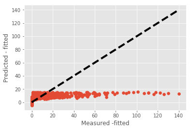

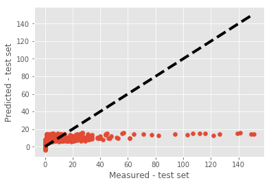

```
Fitted R^2 from training data 0.238598815497
Actual R^2 from test data 0.228633345229
```

```python
#Linear Regression
from sklearn import linear_model
from sklearn import cross_validation
from sklearn.metrics import r2_score
import matplotlib.pyplot as plt

y = df_imputed_reg['MonthsDelinquent'].values # get the labels we want
del df_imputed_reg['MonthsDelinquent'] # get rid of the class label
X = df_imputed_reg.values # use everything else to predict!

# Using 66% to train, 33% to test
Xtrain, Xtest, ytrain, ytest = cross_validation.train_test_split(X, y, test_size= .33, random_state =5)
lm = linear_model.LinearRegression()
model = lm.fit(Xtrain,ytrain)
predictionstrain = lm.predict(Xtrain)
predictionstest = lm.predict(Xtest)
A= np.mean((ytrain - lm.predict(Xtrain)) ** 2)
B= np.mean((ytest - lm.predict(Xtest)) ** 2)
print ('Fit a model X_train and calculate MSE with Y_train', A )
print ('Fit a model X_train and calculate MSE with X_test, Y_test', B )

# The coefficients
print('Coefficients: \n', lm.coef_)
print('Coefficients: \n', lm.intercept_)
# The mean squared error
print("Mean squared error: %.2f"
      % np.mean((lm.predict(Xtest) - ytest) ** 2))
# Explained variance score: 1 is perfect prediction
print('Variance score: %.2f' % lm.score(Xtest, ytest))
fig, ax = plt.subplots()
ax.scatter(ytrain, predictionstrain)
ax.plot([ytrain.min(), ytrain.max()], [ytrain.min(), ytrain.max()], 'k--', lw=4)
ax.set_xlabel('Measured -fitted')
ax.set_ylabel('Predicted - fitted')
plt.show()

fig, ay = plt.subplots()
ay.scatter(ytest, predictionstest)
ay.plot([ytest.min(), ytest.max()], [ytest.min(), ytest.max()], 'k--', lw=4)
ay.set_xlabel('Measured - test set')
ay.set_ylabel('Predicted - test set')
plt.show()
print ( 'Fitted R^2 from training data' , r2_score(ytrain, lm.predict(Xtrain))  )
print ( 'Actual R^2 from test data' , r2_score(ytest, lm.predict(Xtest))  )
```

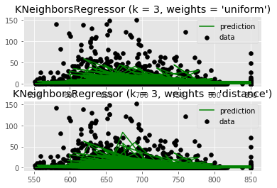

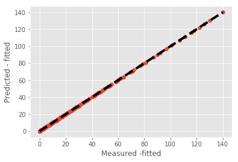

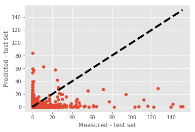

```
Fitted R^2 from training data 1.0
Actual R^2 from training data -0.0702621062581
```

```python
#KNN Regression
import numpy as np
import matplotlib.pyplot as plt
from sklearn import neighbors

n_neighbors = 3

for i, weights in enumerate(['uniform', 'distance']):
    knn = neighbors.KNeighborsRegressor(n_neighbors, weights=weights)
    predictionstrain = knn.fit(Xtrain, ytrain).predict(Xtrain)
    y_ = knn.fit(Xtrain, ytrain).predict(Xtest)

    plt.subplot(2, 1, i + 1)
    plt.scatter(X[:,0], y, c='k', label='data')
    plt.plot(Xtest[:,0], y_, c='g', label='prediction')
    plt.axis('tight')
    plt.legend()
    plt.title("KNeighborsRegressor (k = %i, weights = '%s')" % (n_neighbors,
                                                                weights))
plt.show()

fig, ax = plt.subplots()
ax.scatter(ytrain, predictionstrain)
ax.plot([ytrain.min(), ytrain.max()], [ytrain.min(), ytrain.max()], 'k--', lw=4)
ax.set_xlabel('Measured -fitted')
ax.set_ylabel('Predicted - fitted')
plt.show()

fig, ay = plt.subplots()
ay.scatter(ytest,  y_)
ay.plot([ytest.min(), ytest.max()], [ytest.min(), ytest.max()], 'k--', lw=4)
ay.set_xlabel('Measured - test set')
ay.set_ylabel('Predicted - test set')
plt.show()

print ( 'Fitted R^2 from training data' , r2_score(ytrain, predictionstrain)  )
print ( 'Actual R^2 from training data' , r2_score( ytest, y_)  )
```

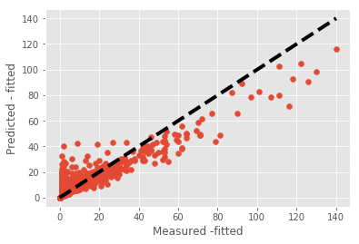

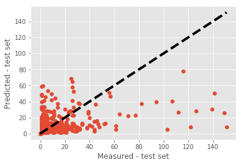

```
Fitted R^2 from training data 0.883281814468
Actual R^2 from tested data 0.275595646348
```

```python
import numpy as np
from sklearn.metrics import accuracy_score
from sklearn.preprocessing import LabelEncoder
from sklearn.ensemble import RandomForestRegressor


regressor = RandomForestRegressor(n_estimators=20, min_samples_split=2)
model = regressor.fit(Xtrain, ytrain)

predictionstrain = regressor.predict(Xtrain)
predictionstest = regressor.predict(Xtest)


fig, ax = plt.subplots()
ax.scatter(ytrain, predictionstrain)
ax.plot([ytrain.min(), ytrain.max()], [ytrain.min(), ytrain.max()], 'k--', lw=4)
ax.set_xlabel('Measured -fitted')
ax.set_ylabel('Predicted - fitted')
plt.show()

fig, ay = plt.subplots()
ay.scatter(ytest,  predictionstest)
ay.plot([ytest.min(), ytest.max()], [ytest.min(), ytest.max()], 'k--', lw=4)
ay.set_xlabel('Measured - test set')
ay.set_ylabel('Predicted - test set')
plt.show()


from sklearn.metrics import r2_score
print ('Fitted R^2 from training data' , r2_score(ytrain, predictionstrain))
print ('Actual R^2 from tested data' , r2_score(ytest, predictionstest))
```

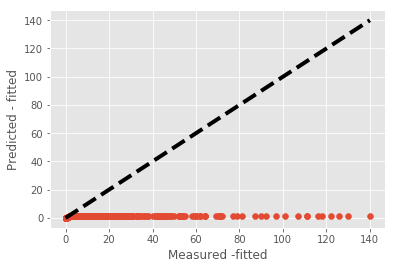

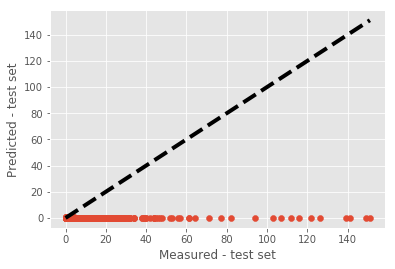

```
Fitted R^2 from training data 0.0186823256281
Actual R^2 from tested data -0.0273750245445
```

```python
from sklearn import svm
svlf = svm.SVR()
model = svlf.fit(Xtrain, ytrain)
predictionstrain = svlf.predict(Xtrain)
predictionstest = svlf.predict(Xtest)
fig, ax = plt.subplots()
ax.scatter(ytrain, predictionstrain)
ax.plot([ytrain.min(), ytrain.max()], [ytrain.min(), ytrain.max()], 'k--', lw=4)
ax.set_xlabel('Measured -fitted')
ax.set_ylabel('Predicted - fitted')
plt.show()
fig, ay = plt.subplots()
ay.scatter(ytest,  predictionstest)
ay.plot([ytest.min(), ytest.max()], [ytest.min(), ytest.max()], 'k--', lw=4)
ay.set_xlabel('Measured - test set')
ay.set_ylabel('Predicted - test set')
plt.show()
from sklearn.metrics import r2_score
print ('Fitted R^2 from training data' , r2_score(ytrain, predictionstrain))
print ('Actual R^2 from tested data' , r2_score(ytest, predictionstest))
```

From all of the above regression methods, we can arrive at a conclusion that for this data fitting a model that can predic the value of months that a potential borrower could be delinquent upto, is a difficult task and the best model we could come up with for it was a random forest regression model with a rSquared value of around .27

Back to Index

# References

In completing our work we referenced the course notebooks and scikit learn documentation located below.

- https://github.com/eclarson/DataMiningNotebooks
- http://scikit-learn.org/stable/supervised_learning.html#supervised-learning